# Lab08

tony sulfaro

2/27/2019

## Load the libraries

```r
library(tidyverse)
```

## Load the data

```r
election2016 <- read_csv("Week5_Lab_election2016_data.csv")
```

## Describe the dataset

The election2016 dataset contains data collected about the outcome of the US presidential election in 2016. There is one row per state in the US, and each row has information about how the election went in that state. For example, there’s a column for which candidate won the election in that state and what party they’re from. There’s columns for how many people voted in each state, what the vote margin for the winner was in that state, and how many percentage points difference there was. There are also some columns about the population composition of each state: the proportion of the state that lives in cities, the percent of the population that was not white, an estimate of the 2016 population based on annual census surveys, and the percent of the population that voted in the presidential election in 2016. This dataset can be used to answer questions about the relationship between state population characteristics and which candidate won the election in each state. Documentation for the dataset is available in the file: Week5_Lab_data_documentation.txt.

```r
str(election2016)
```

```
## Classes 'spec_tbl_df', 'tbl_df', 'tbl' and 'data.frame': 50 obs. of  13 variables:
##  $ state                : chr  "Alabama" "Alaska" "Arizona" "Arkansas" ...
##  $ st                   : chr  "AL" "AK" "AZ" "AR" ...
##  $ total_vote           : num  2123372 318608 2604657 1130635 14237884 ...
##  $ vote_margin          : num  588708 46933 91234 304378 4269978 ...
##  $ winner               : chr  "Trump" "Trump" "Trump" "Trump" ...
##  $ party                : chr  "Republican" "Republican" "Republican" "Republican" ...
##  $ d_points             : num  -27.7 -14.7 -3.5 -26.9 30 ...
##  $ region               : chr  "South" "West" "West" "South" ...
##  $ pct_pop_metro        : num  64 63 90 69 97 80 94 90 96 82 ...
##  $ pct_non_white        : num  35 42 49 26 61 31 30 37 46 48 ...
##  $ pop_2016             : num  4864745 741504 6945452 2990410 39209127 ...
##  $ pct_voted            : num  43.6 43 37.5 37.8 36.3 ...
##  $ non_white_over_30_pct: logi  TRUE TRUE TRUE FALSE TRUE TRUE ...
##  - attr(*, "spec")=
##   .. cols(
##   ..   state = col_character(),
##   ..   st = col_character(),
##   ..   total_vote = col_double(),
##   ..   vote_margin = col_double(),
##   ..   winner = col_character(),
##   ..   party = col_character(),
##   ..   d_points = col_double(),
##   ..   region = col_character(),
##   ..   pct_pop_metro = col_double(),
##   ..   pct_non_white = col_double(),
##   ..   pop_2016 = col_double(),
##   ..   pct_voted = col_double(),
##   ..   non_white_over_30_pct = col_logical()
##   .. )
```

```r
nrow(election2016)
```

```
## [1] 50
```

```r
ncol(election2016)
```

```
## [1] 13
```

## Basic scatterplot

Below is a basic scatterplot. The x-axis is the percent of the population that lives in an urban area, and the y-axis is the percentage point difference in votes between Clinton and Trump. In this graph, the first thing that stands out is that the points are arranged in a diagonal line pattern from the lower left to the upper right of the graph. The graph shows that as more of a state’s population lives in an urban area, Clinton was more likely to win the election in that state.

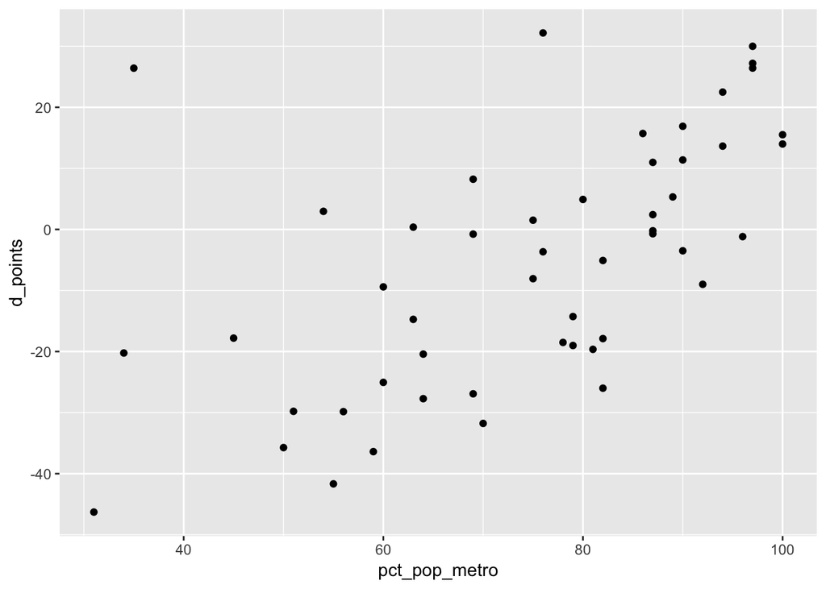

```r
ggplot(data=election2016) +
  geom_point(aes(x=pct_pop_metro, y=d_points))
```

The graph below is the same graph, but with a title, caption, and more user-friendly x-axis and y-axis labels added. You can learn about how to do this at [this web page](https://ggplot2.tidyverse.org/reference/labs.html).

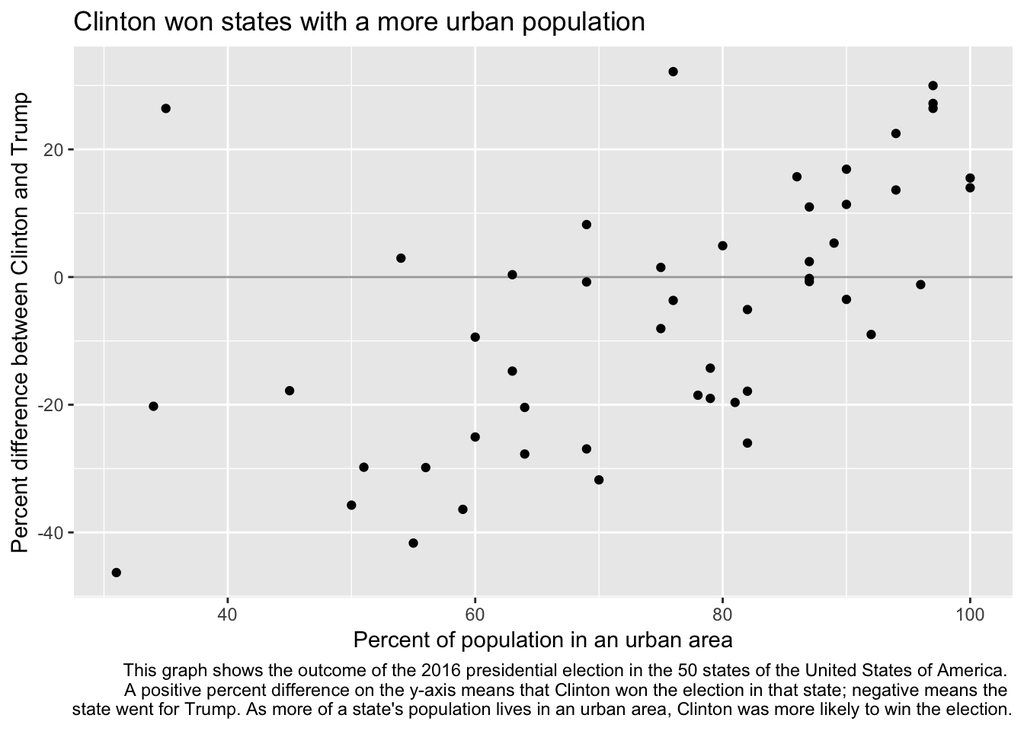

```r
ggplot(data=election2016) +
  geom_hline(yintercept=0, color="darkgray") +
  geom_point(aes(x=pct_pop_metro, y=d_points)) +
  labs(title = "Clinton won states with a more urban population", caption = "This graph shows the outcome of the 2016 presidential election in the 50 states of the United States of America. \nA positive percent difference on the y-axis means that Clinton won the election in that state; negative means the \nstate went for Trump. As more of a state's population lives in an urban area, Clinton was more likely to win the election.") +
  xlab("Percent of population in an urban area") +
  ylab("Percent difference between Clinton and Trump")
```

## Revised scatterplot

This graph is a revised version of the previous scatterplots, made to look more beautiful, functional, and insightful. A third variable has been added, to color the points according to the winner of the 2016 election in each state. A fourth variable has also been added; the size of the points represents the proportion of the population in each state that is a racial minority. The pattern that this variable shows is that Clinton won more of the states that had a larger proportion of minority voters.

```r
party_colors = c("blue", "red")
```

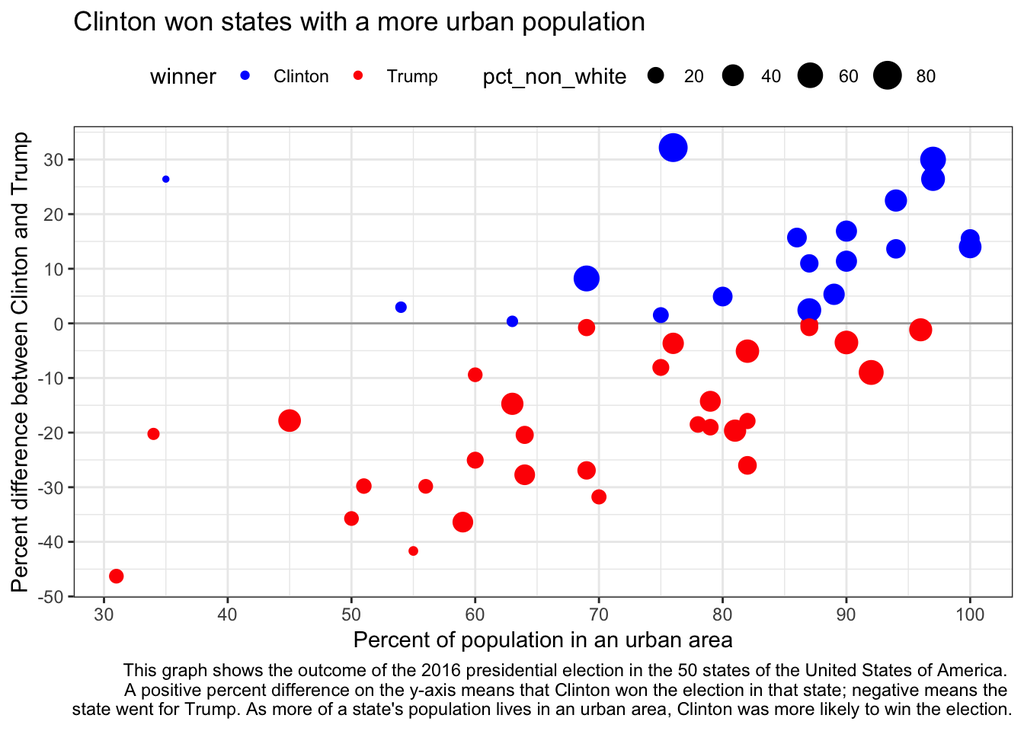

```r
ggplot(data=election2016) +
  geom_hline(yintercept=0, color="darkgray") +
  geom_point(aes(x=pct_pop_metro, y=d_points, color=winner, size=pct_non_white)) +
  scale_color_manual(values=party_colors) +
  theme_bw() +
  scale_y_continuous(breaks=seq(-50, 40, 10)) +
  scale_x_continuous(breaks=seq(20, 100, 10)) +
  theme(legend.position="top") +
  labs(title = "Clinton won states with a more urban population", caption = "This graph shows the outcome of the 2016 presidential election in the 50 states of the United States of America. \nA positive percent difference on the y-axis means that Clinton won the election in that state; negative means the \nstate went for Trump. As more of a state's population lives in an urban area, Clinton was more likely to win the election.") +
  xlab("Percent of population in an urban area") +
  ylab("Percent difference between Clinton and Trump")
```

## An additional graph

The graph below uses the following variables:

- pct_voted: The percent of the state’s population that voted, calculated based on the total number of votes cast and the estimated population of the state in 2016
- pct_non_white: The percent of the population that was not white, in 2015
- winner: The winner of the election in that state
- vote_margin: The vote margin of the winner in that state (how many votes they won by)

There is a diagonal pattern from the top left to the bottom right of the graph. This means that fewer people voted in states with a greater minority population, relatively speaking. Also, the size of the points represents the vote margin for the winner, and the blue circles seem like they tend to be bigger than the red circles. This means that where Clinton won, she won by a bigger margin than where Trump won.

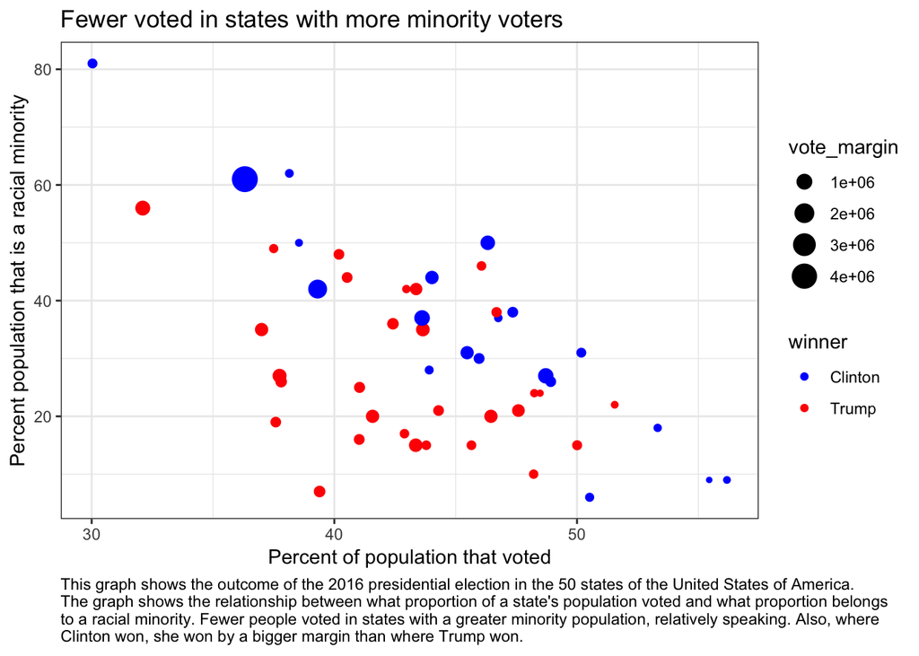

```r
ggplot(data=election2016) +
    geom_point(aes(x=pct_voted, y=pct_non_white, color=winner, size=vote_margin)) +
    scale_color_manual(values=party_colors) + theme_bw() +
    labs(title = "Fewer voted in states with more minority voters", caption = "This graph shows the outcome of the 2016 presidential election in the 50 states of the United States of America. \nThe graph shows the relationship between what proportion of a state's population voted and what proportion belongs \nto a racial minority. Fewer people voted in states with a greater minority population, relatively speaking. Also, where \nClinton won, she won by a bigger margin than where Trump won.") +
    xlab("Percent of population that voted") +
    ylab("Percent population that is a racial minority") +
  theme(plot.caption=element_text(hjust=0)) ## left-justify the caption
```